# Estimated Delivery Date Prediction

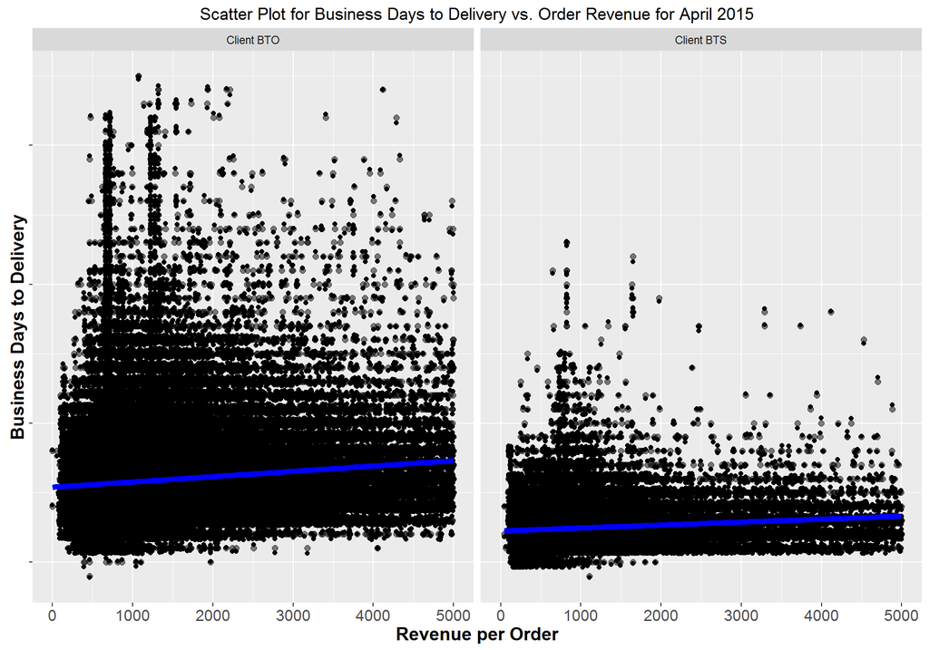

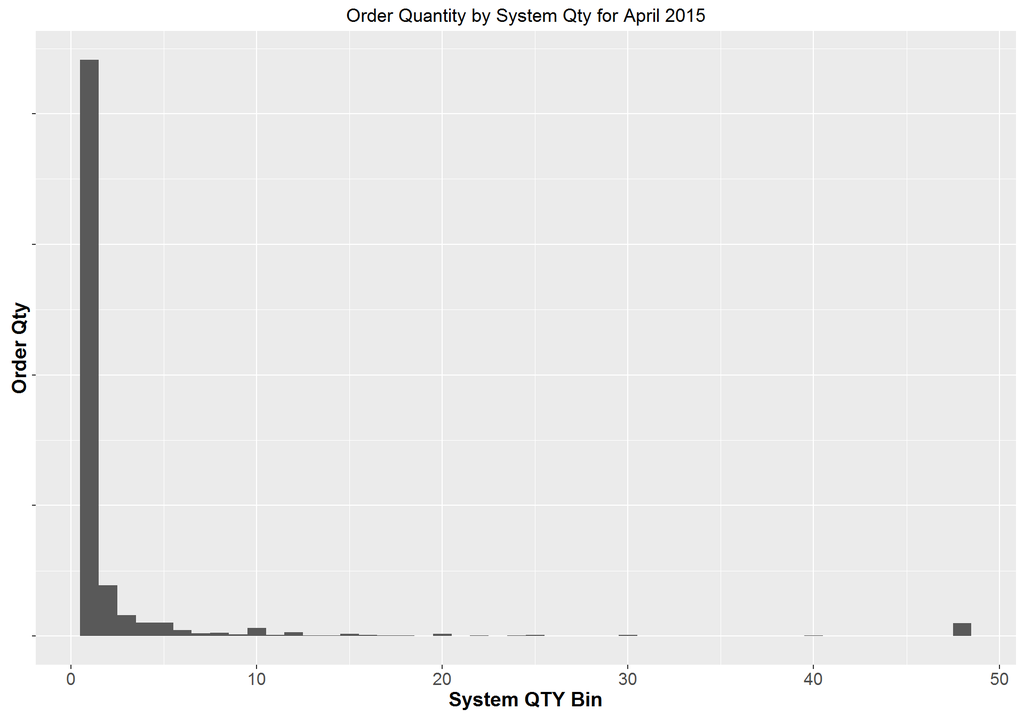

Almost 80% of order have only 1 system on them. Interesting data point at system quantity = 48.

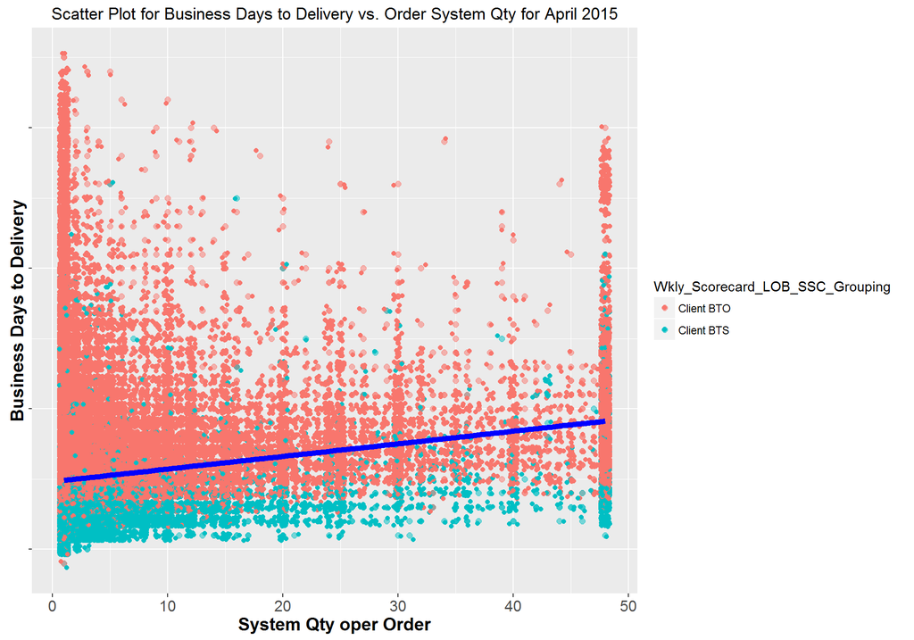

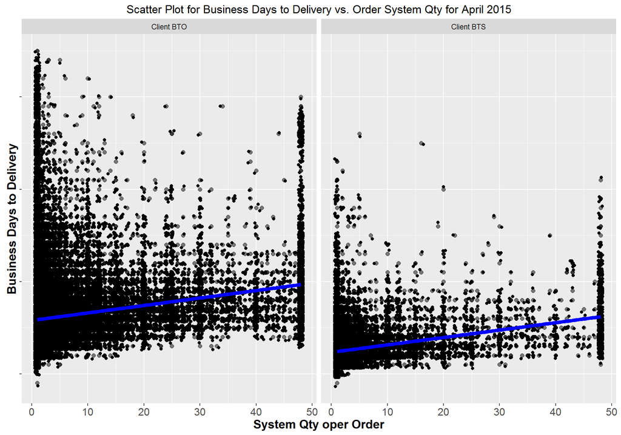

It looks like the more systems on an order the more time it takes per the scatter plot

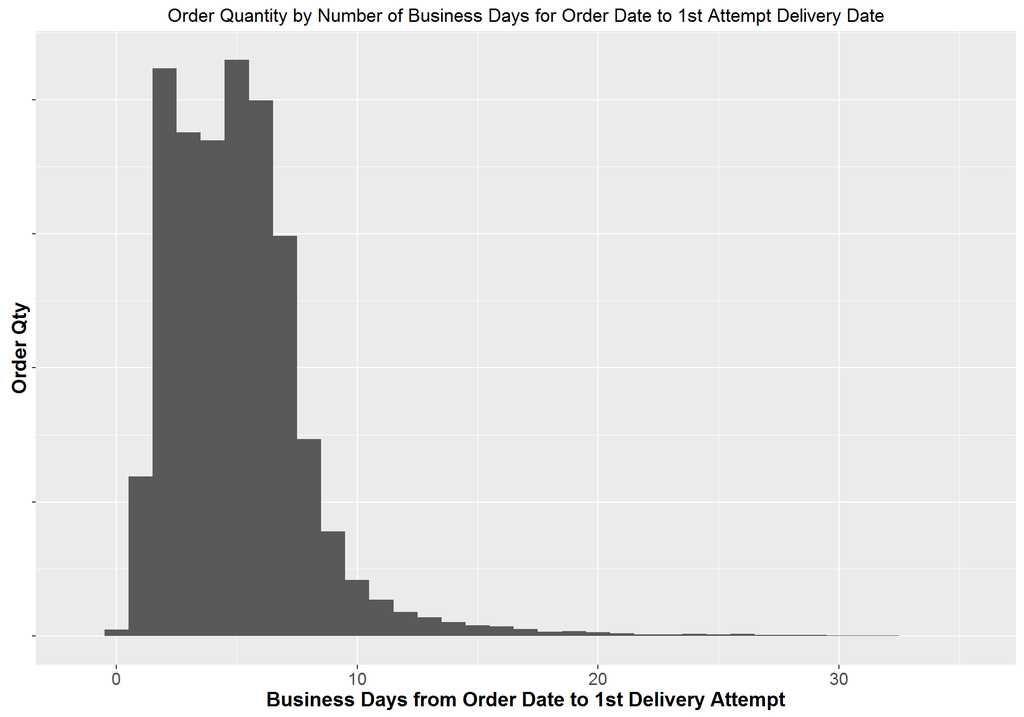

Mean number of business days from Order Date to 1st attempt Delivery Date is 5.1 Days, Median is 5 days, with 1st quartile at 3 days and 3rd quartile at 6 days. It seems that there may be a binomial distributions (Client BTS vs. Client BTO)

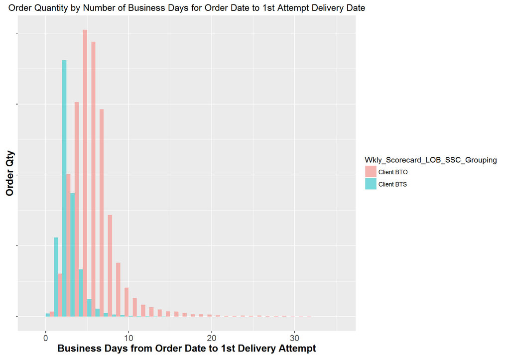

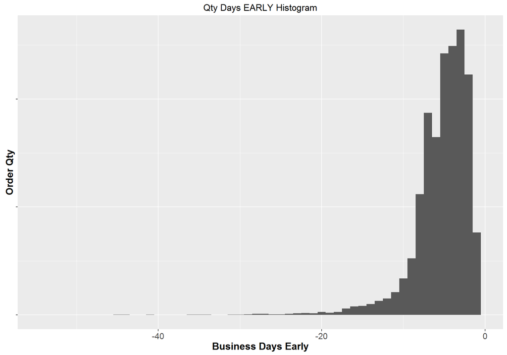

Early deliveries arrive on average -5.3 business days before the date communicated to the customer (median = - 5 days) standard dev is 3.6 days

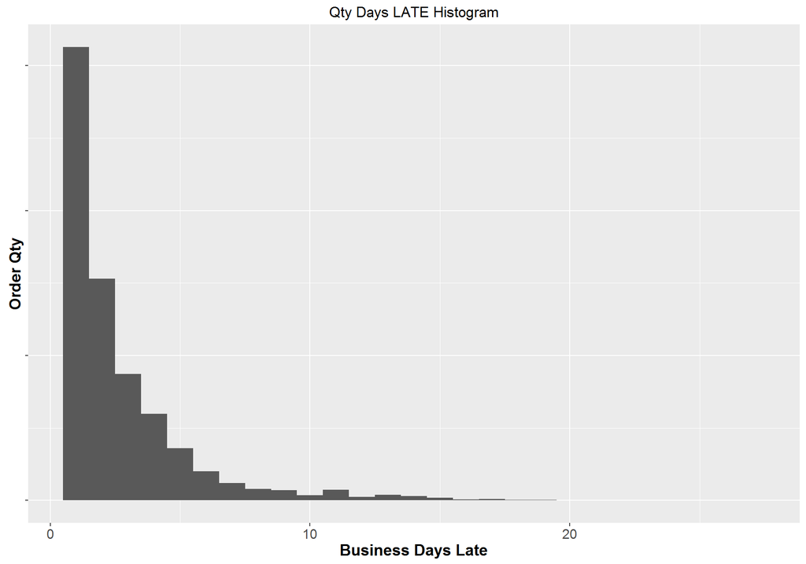

Late deliveries arrive on average + 2.7 business days bafter the date communicated to the customer (median = +2 days) standard dev is 2.5 days.

### **Feature Selection**:

With over 50 features to choose from, the next step was to determine which features had the largest impact on the target variable (quantity of business days from order date to delivery date) and to ensure that the correlation between features was well understood.

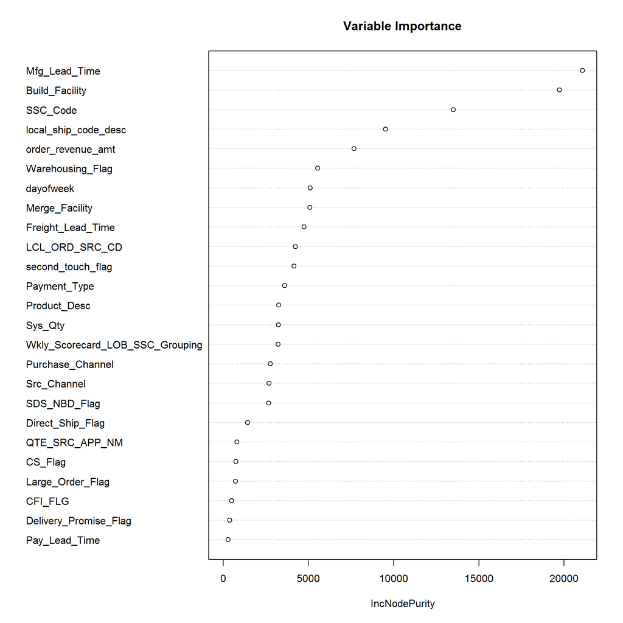

After splitting the data into a training set (80% of the observations) and a test set (20% of observations), a Random Forest model was used as a first pass to determine varaible importance. From the Random Forest model we see that Mfg_Lead_Time, Build_Facility, SSC_Code, local_ship_code_desc, order_revenue_amt are the top 5 variables in terms of importance to delivery days.

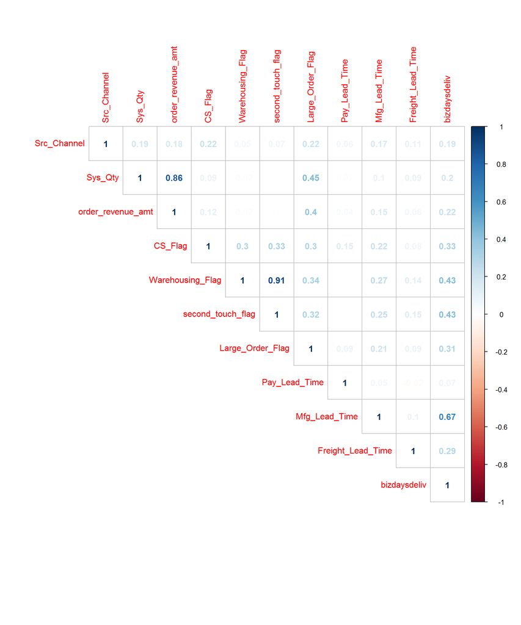

Focussing on the target variable (bizdaysdeliv), we find that Mfg_Lead_Time has a strong correlation to it at 0.67 followed by Warehousing_Flag and second_touch_flag both at 0.43. However, we can also see that Warehousing_Flag and second_touch_flag are hihgly correlated to one another, and since we met with the busines process subject matter experts we detemrined that Warehousing_Flag would be the one to keep in the model. Another strong correlation between independent features is Sys_Qty to order_revenue_amt and to Large_Order_Flag. Again based on the deep understanding of the process, we will only use Sys_Qty in our prediciton model.

### **Modeling**:

Since we are trying to predict the number of business days from order date to delivery date, we need to use a regression modleing technique to do this kind of predection (vs. using a classification modeling technique). The first step used was to spot check several algorithms and determine how well they would perform on the training data. RMSE and R-squared were used as the key metrics in identifying the model(s) that performed best on the training data. Below is a summary of each model’s performance. GBM was found to have the best performance with the lowest RMSE of 1.67 days and an Rsquared value of ~0.71.

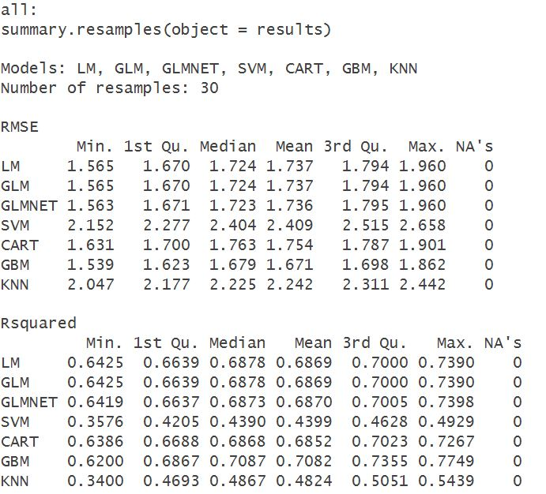

### **Model Tuning**:

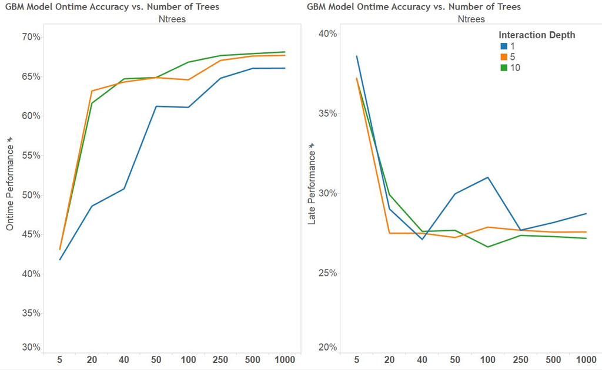

### **Next Steps**:

The key next steps include the following:

1. Determine if we can better set the window range used to communicate delivery times to our customers based on more probablisitic range logic using a porbabilibty density function. We will need to ensure that any new range logic is competitive and acceptable to our customer base.
2. Integrate the tuned GBM model into our real time process workflow
3. Monitor model performance and continue to tune it as needed

### **Appendix**:

### **Clustering**:

One thought was to cluster the order data to determine if there were unique and meaningful clusters that could be identified and then build predictive models for each cluster to see if we could improve ontime performance.

Since the features used were mixed of mixed types (e.g.nominal and factor, all the pairwise dissimilarities (distances) between observations in the data set were calculated using “gower” distance. A hierarchacal clustering algorith was used. From the dendogram below, it looks like ~5 clusters would be most meaningful.

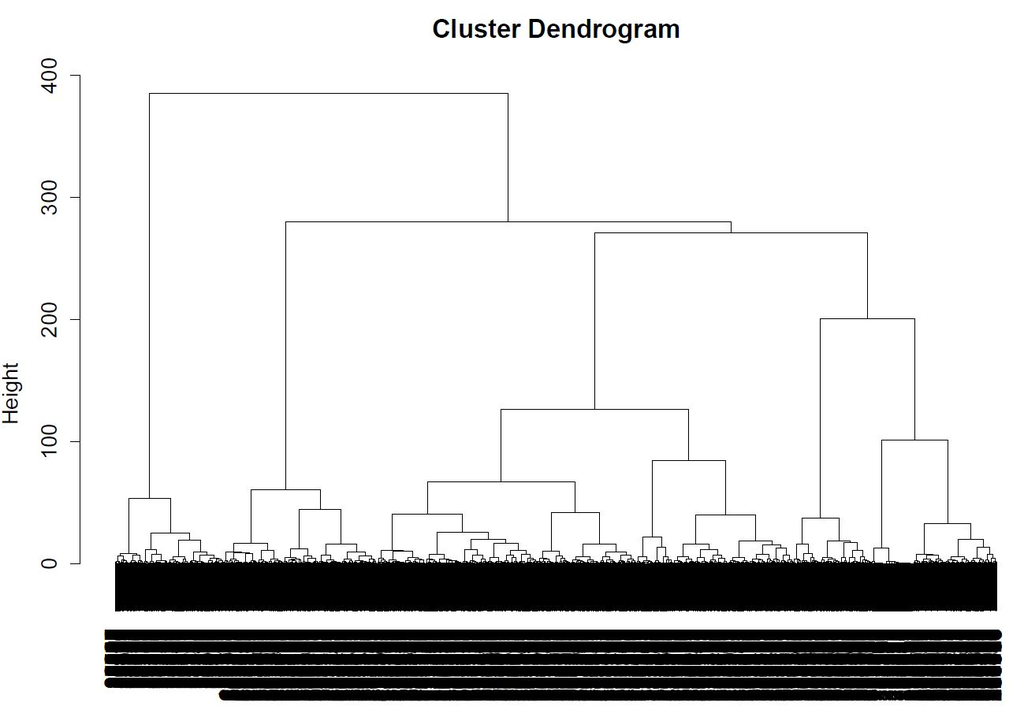

To confirm that 5 is the optimal number of clusters, a silhouette width was calculated.

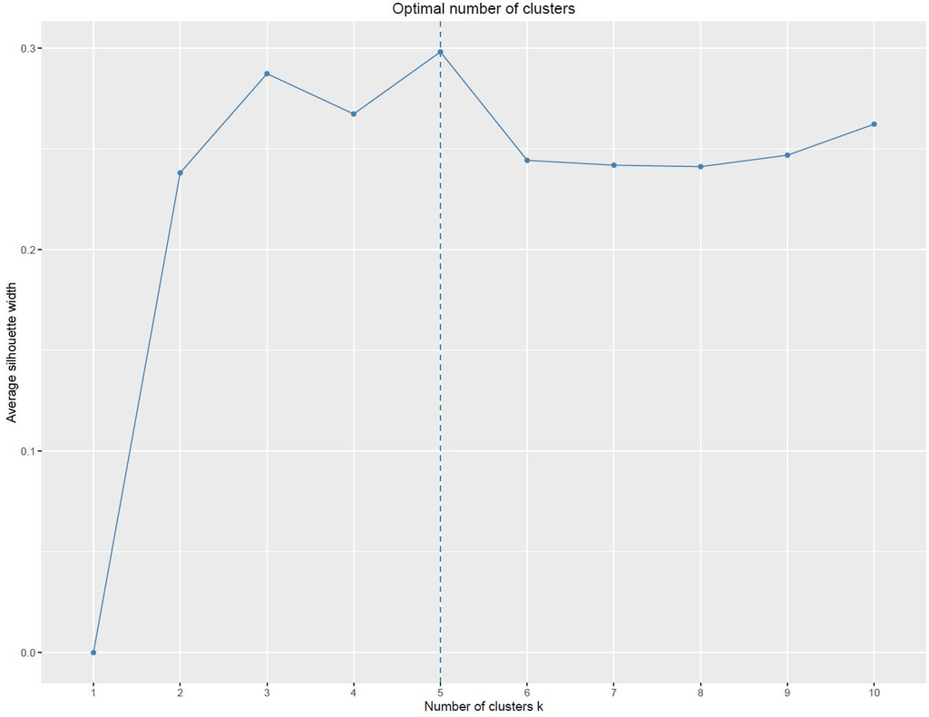

5 clusters were confirmed through silhouette width.

In order to better understand each cluster, they were plotted and analyzed. Clusters 1, 2 consisted of BTO product that were non CFI while cluster 3 was heavy BTO product with CFI. Cluster 4 was found to be mainly composed of BTS.

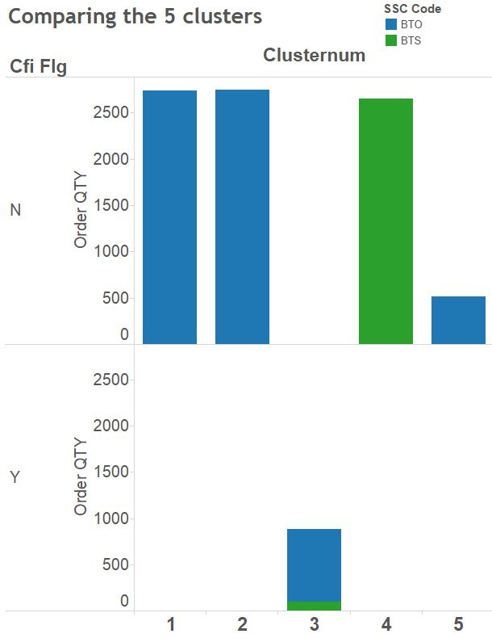

In order to determine the difference between clusters 1 & 2, they were further analyzed and it was found that cluster 1 was made up mainly 3-5 day shipment method while cluster 2 was composed more of premium next day and 2nd day shipment.

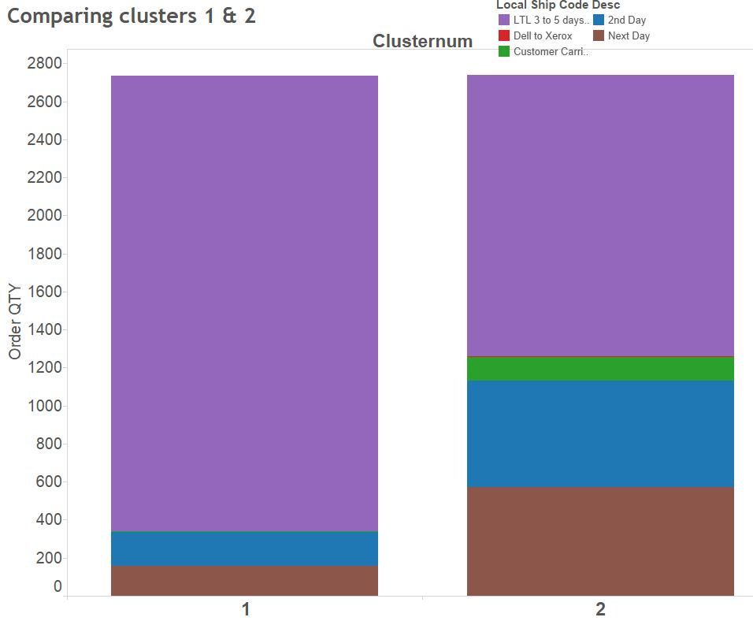

THe idea was to split the data into BTO and BTS populations to determine if different models would work better on BTO vs. BTS, but in the end GBM was found to have the best performance for both BTS and BTO populations.